# MIS40970 - Data Mining for Business Analytics

Deepak Kumar Gupta (MScBA - 16200660)

Due Date: Feb 15, 2017

# 1 Load the oj.csv data into R.

```r
options(warn = 1)
oj <- read.csv(file="oj.csv",head=TRUE,sep=",")
summary(oj)
```

```
     store                brand           week          logmove            feat            price
 Min.   :  2.00   dominicks  :9649   Min.   : 40.0   Min.   : 4.159   Min.   :0.0000   Min.   :0.520
 1st Qu.: 53.00   minute.maid:9649   1st Qu.: 70.0   1st Qu.: 8.490   1st Qu.:0.0000   1st Qu.:1.790
 Median : 86.00   tropicana  :9649   Median :101.0   Median : 9.034   Median :0.0000   Median :2.170
 Mean   : 80.88                      Mean   :100.5   Mean   : 9.168   Mean   :0.2373   Mean   :2.282
 3rd Qu.:111.00                      3rd Qu.:130.0   3rd Qu.: 9.765   3rd Qu.:0.0000   3rd Qu.:2.730
 Max.   :137.00                      Max.   :160.0   Max.   :13.482   Max.   :1.0000   Max.   :3.870
     AGE60              EDUC             ETHNIC            INCOME          HHLARGE
 Min.   :0.05805   Min.   :0.04955   Min.   :0.02425   Min.   : 9.867   Min.   :0.01351
 1st Qu.:0.12210   1st Qu.:0.14598   1st Qu.:0.04191   1st Qu.:10.456   1st Qu.:0.09794
 Median :0.17065   Median :0.22939   Median :0.07466   Median :10.635   Median :0.11122
 Mean   :0.17313   Mean   :0.22522   Mean   :0.15556   Mean   :10.617   Mean   :0.11560
 3rd Qu.:0.21395   3rd Qu.:0.28439   3rd Qu.:0.18776   3rd Qu.:10.797   3rd Qu.:0.13517
 Max.   :0.30740   Max.   :0.52836   Max.   :0.99569   Max.   :11.236   Max.   :0.21635
    WORKWOM          HVAL150            SSTRDIST          SSTRVOL          CPDIST5
 Min.   :0.2445   Min.   :0.002509   Min.   : 0.1321   Min.   :0.4000   Min.   :0.7725
 1st Qu.:0.3126   1st Qu.:0.123486   1st Qu.: 2.7670   1st Qu.:0.7273   1st Qu.:1.6262
 Median :0.3556   Median :0.346154   Median : 4.6507   Median :1.1154   Median :1.9634
 Mean   :0.3592   Mean   :0.343766   Mean   : 5.0973   Mean   :1.2073   Mean   :2.1204
 3rd Qu.:0.4023   3rd Qu.:0.528313   3rd Qu.: 6.6506   3rd Qu.:1.5385   3rd Qu.:2.5337
 Max.   :0.4723   Max.   :0.916700   Max.   :17.8560   Max.   :2.5714   Max.   :4.1079
    CPWVOL5
 Min.   :0.09456
 1st Qu.:0.27167
 Median :0.38323
 Mean   :0.43891
 3rd Qu.:0.56024
 Max.   :1.14337
```

# 2 How many records and how many attributes are in the orange juice dataset?

There are 28947 records and 17 attributes.

```r
#Method 1
dim(oj)
```

```
[1] 28947    17
```

```r
#Method 2
nrow(oj)
```

```
[1] 28947
```

```r
ncol(oj)
```

```
[1] 17
```

```r
names(oj)
```

```
 [1] "store"    "brand"    "week"     "logmove"  "feat"     "price"    "AGE60"    "EDUC"     "ETHNIC"
[10] "INCOME"   "HHLARGE"  "WORKWOM"  "HVAL150"  "SSTRDIST" "SSTRVOL"  "CPDIST5"  "CPWVOL5"
```

# 3 What is the mean, standard deviation and range of the price of orange juice?

```r
mean(oj$price)
```

```
[1] 2.282488
```

```r
sd(oj$price)
```

```
[1] 0.6480007
```

```r
range(oj$price)
```

```
[1] 0.52 3.87
```

# 4 What is the median of the ‘log of number of units sold’ (logmove)?

Median is 9.03408

```r
median(oj$logmove)
```

```
[1] 9.03408
```

# 5 What are the names of the 3 orange juice brands?

- Juice Brands are:
1. Dominicks
2. Minute.maid
3. Tropicana

```r
#Method 1
unique(oj$brand)
```

```
[1] tropicana   minute.maid dominicks
Levels: dominicks minute.maid tropicana
```

```r
#Method 2
juicebrand<- factor(oj$brand)
table(juicebrand)
```

```
juicebrand
  dominicks minute.maid   tropicana
       9649        9649        9649
```

# 6 Create a histogram of prices for each brand of orange juice.

## 6.1 Method 1: using hist()

```r
library(lattice)
par(mfrow = c(3,1))
hist(oj$price[oj$brand=='tropicana'],main=" Price of Tropicana Orange Juice"
       ,xlab="Price",breaks =50, col = 'brown')
hist(oj$price[oj$brand=='minute.maid'],main=" Price of Mindute Maid Orange Juice"
       ,xlab="Price",breaks =50,col='Red')
```

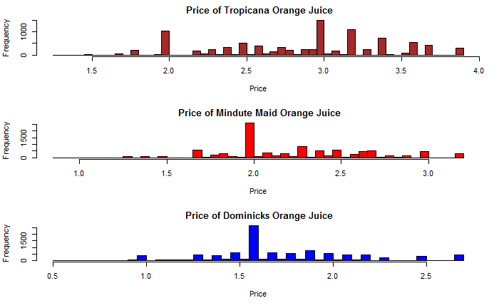

```r
hist(oj$price[oj$brand=='dominicks'],main=" Price of Dominicks Orange Juice"
     ,xlab="Price",breaks =50, col = 'blue')
```

## 6.2 Method 2: Using ggplot2()

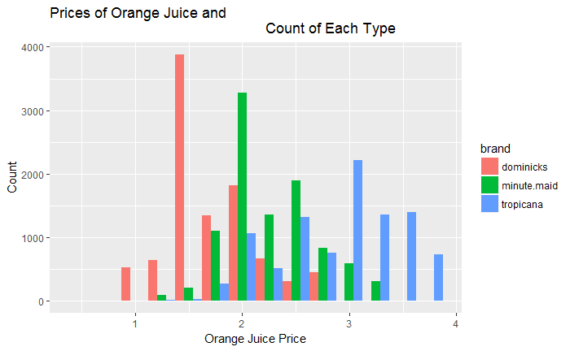

```r
library(ggplot2)
par(mfrow = c(3,3))
ggplot(oj, aes(x= oj$price, fill = brand)) + geom_histogram(binwidth=0.25,position = "dodge")+
ylab("Count") + xlab("Orange Juice Price") + ggtitle("Prices of Orange Juice and
                                                     Count of Each Type")
```

## 6.3 Method 3: Using histogram()

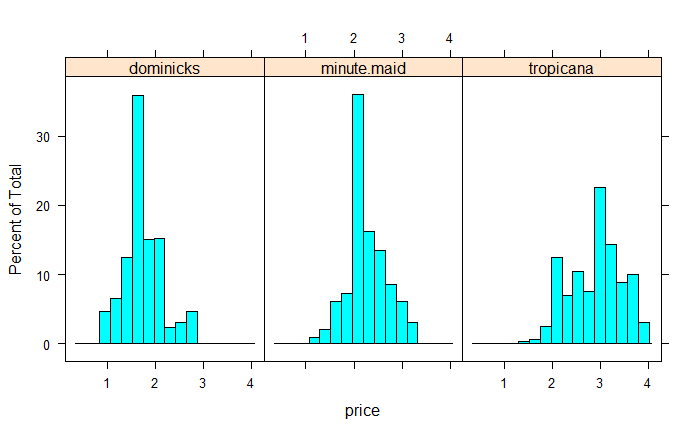

```r
histogram(~price|brand,data=oj,layout=c(3,1))
```

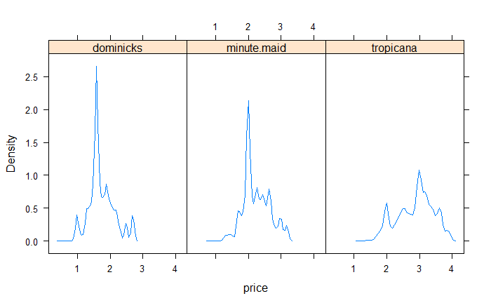

```r
densityplot(~price|brand,data=oj,layout=c(3,1),plot.points=FALSE)
```

# 7 Generate a boxplot, which includes a separate plot for the prices of each brand

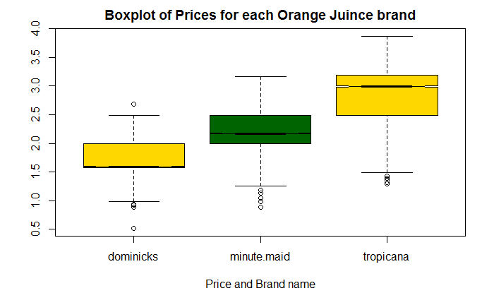

```r
boxplot(oj$price~oj$brand, data=oj, notch=TRUE,
  col=(c("gold","darkgreen")),main="Boxplot of Prices for each Orange Juince brand",
  xlab="Price and Brand name")
```

# 8 What does the boxplot tell us about the relative prices of each brand?

- Dominick’s has outlier less than 3/2 times of lower quartile. one outlier is more than 3/2 time of upper quartile. Also, majority of price range of Dominick’s is more than the median value and it has range of 1.6 to 2 (approx)
- Minute.maid has about 5 outliers less than 3/2 times of lower quartile.
- Tropicana has few outliers closer to the minimum of lower quartile whiskers. Overall, with the help of boxplot, one can interpret the distribution of figure around quartile of a median value. That will help a user to identify outlier values and then perform detailed data analysis to find trends and pattern among datasets.